# Домашнее задание 2

## часть 1

```python
last_name = 'Соболев'
g = 'ИУ3-51'
student_id = '16У169'
```

### Задание 1

Создайте функцию, принимающую на вход целое число `n` и вовращающую диагональную матрицу порядка `n` с элементами главной диагонали равными `n`:

```python
import numpy as np

def f1(n):
    """
    Parameters
    ----------
    n: int

    Returns
    -------
    np.array, shape=(n,n)
    """
    diagon_matrix = np.zeros((n,n))
    diagon_matrix = diagon_matrix.astype(int)
    diagon_matrix[np.diag_indices_from(diagon_matrix)] = n
    return diagon_matrix

f1(7)
```

```
array([[7, 0, 0, 0, 0, 0, 0],
       [0, 7, 0, 0, 0, 0, 0],
       [0, 0, 7, 0, 0, 0, 0],
       [0, 0, 0, 7, 0, 0, 0],
       [0, 0, 0, 0, 7, 0, 0],
       [0, 0, 0, 0, 0, 7, 0],
       [0, 0, 0, 0, 0, 0, 7]])
```

### Задание 2

Создайте функцию, принимающую на вход целое число `n` и вовращающую массив из `n` равномерно распределенных значений в диапазоне `[0; 1]`

```python
def f2(n):
    """
    Parameters
    ----------
    n: int

    Returns
    -------
    np.array, shape=(n,)
    """
    return np.random.rand(n)

f2(40)
```

```
array([0.36738811, 0.82168048, 0.01653081, 0.08020378, 0.25175942,
       0.71569281, 0.47188346, 0.46384411, 0.01764278, 0.60266827,
       0.17144091, 0.31651516, 0.59947044, 0.11115019, 0.41511057,
       0.34502644, 0.61428171, 0.65392101, 0.7235439 , 0.15705398,
       0.56483888, 0.51806972, 0.54748454, 0.96398901, 0.97497382,
       0.26177665, 0.46971176, 0.73693818, 0.67481289, 0.7430087 ,
       0.98105295, 0.53822234, 0.56095174, 0.46466691, 0.56223205,
       0.27644042, 0.40572529, 0.28490572, 0.07497796, 0.90656482])
```

### Задание 3

Создайте функцию, принимающую на вход число `n` и одномерный numpy-массив `arr` и заменяющую в массиве все четные элементы (четный именно элемент, а не его индекс) на `n`. Верните измененный массив.

```python
def f3(n, arr):
    """
    Parameters
    ----------
    n: int
    arr: np.array, shape=(x, )

    Returns
    -------
    np.array, shape=(x,)
    """
    array_length = arr.shape[0]

    for j in range(array_length):
        if not arr[j] % 2:
            arr[j] = n
    return arr

f3(16, np.array([2, 23, 37, 54, 86, 131, 219, 357, 568, 903, 708, 1024, 267, 202]))
```

```
array([ 16,  23,  37,  16,  16, 131, 219, 357,  16, 903,  16,  16, 267,
        16])
```

### Задание 4

Создайте функцию, принимающую на вход два одномерных numpy-массива и возвращающую numpy-массив индексов, на которых значения массивов совпадают.

```python
def f4(a, b):
    """
    Parameters
    ----------
    n: int
    arr: np.array, shape=(x, )

    Returns
    -------
    np.array, shape=(x,)
    """
    array_length = min(a.shape[0], b.shape[0])
    result_mas = []

    for i in range(array_length):
        if a[i] == b[i]:
            result_mas.append(i)

    return np.array(result_mas)

f4(np.array([10, 20, 30, 40, 50, 60, 70, 80, 90, 201]), np.array([50, 20, 65, 40, 98, 60, 121, 80, 95, 201]))
```

```
array([1, 3, 5, 7, 9])
```

### Задание 5

Создайте функцию, принимающую на вход одномерный numpy-массив и находящий элемент `а` с наибольшей частотой `с` в одномерном массиве

```python
def f5(arr):
    """
    Parameters
    ----------
    arr: np.array, shape=(x, )

    Returns
    -------
    a: int
    c: int
    """
    uniq_elems, count_elems = np.unique(arr, return_counts = True)

    maximal_frequency = np.where(count_elems == max(count_elems))

    a = int(uniq_elems[maximal_frequency])
    c = int(count_elems[maximal_frequency])


    return (a, c)

a, c = f5(np.array([8, 41, 42, 5, 42, 42, 5, 53, 8, 42, 8, 42]))
print('a:', a, '\t c:', c)
```

```
a: 42 	 c: 5
```

### Задание 6

Создайте функцию принимающую на вход одномерный массив и число a, берет каждый а-тый элемент из него (ведем отсчет с нулевого элемента и включаем его) и возвращает среднее, медиану и СКО для полученного массива

```python
def f6(arr, a):
    """
    Parameters
    ----------
    arr: np.array, shape=(x, )
    a: int

    Returns
    -------
    mean: int
    median: int
    std: int
    """
    my_array = []
    my_index = 0

    while my_index < len(arr):
        my_array.append(arr[my_index])
        my_index += a

    my_array = np.array(my_array)

    mean = np.mean(my_array)
    median = np.median(my_array)
    std = np.std(my_array)

    return mean, median, std

mean, median, std = f6(np.array([8, 54, 5, 74, 142, 52, 34, 57, 45, 223, 1271, 42, 74, 254, 634, 231, 954, 71, 235, 456]), 1)
print('Среднее:\t {} \nМедиана:\t {} \nСКО:\t\t {}'.format(mean, median, std))
```

```
Среднее:	 245.8
Медиана:	 74.0
СКО:		 331.661514197834
```

### Задание 7

Создайте функцию, принимающую на вход двумерный numpy-массив, и 4 числа (i, j, a, b) и возвращающий массив таких строк входного массива, в которых элемент i-го столбца меньше a и элемент j-го столбца больше b.

```python
def f7(arr, i, j, a, b):
    """
    Parameters
    ----------
    arr: np.array, shape=(x, y)
    i: int, first index
    j: int, second index
    a: first bound
    b: second bound

    Returns
    -------
    np.array, shape=(x, z), z <= y
    """

    matrix_height = arr.shape[0]
    matrix_width = arr.shape[1]

    is_element_i_less_than_a = False
    is_element_j_less_than_b = False

    my_array = []

    for index_stroki in range(matrix_height):

        is_element_i_less_than_a = False
        is_element_j_less_than_b = False

        for index_stolbtsa in range(matrix_width):


            if index_stolbtsa == i and arr[index_stroki, index_stolbtsa] < a:
                is_element_i_less_than_a = True

            if index_stolbtsa == j and arr[index_stroki, index_stolbtsa] > b:
                is_element_j_less_than_b = True


        if is_element_i_less_than_a and is_element_j_less_than_b:
                my_array.append(arr[index_stroki])

    if my_array == []:
            return


    return np.array(my_array)

f7(np.array([[8, 7, 23, 5, 7, 45, 9, 7], [7, 24, 11, 4, 51, 10, 27, 54]]), i = 3, j = 7, a = 5, b = 6)
```

```
array([[ 7, 24, 11,  4, 51, 10, 27, 54]])
```

### Задание 8

Создайте функцию, принимающую на вход двумерный numpy-массив и нормирующий значения в каждой строке (`x`) в диапазоне от 0 до 1 (минимальный элемент должен стать равным 0, а максимальный - равным 1)

```
input:
array([[1, 2, 3, 4],
       [0, 2, 4, 8]])

output:
array([[0.        , 0.33333333, 0.66666667, 1.        ],
       [0.        , 0.25      , 0.5       , 1.        ]])
```

```python
def f8(arr):
    """
    Parameters
    ----------
    arr: np.array, shape=(x, y)

    Returns
    -------
    np.array, shape=(x, y)
    """
    matrix_height = arr.shape[0]
    matrix_width = arr.shape[1]

    normalized_matrix = np.zeros((matrix_height, matrix_width))

    for index_stroki in range(matrix_height):

        minimal_simbol_v_stroke = min(arr[index_stroki])
        maximal_simbol_v_stroke = max(arr[index_stroki])

        for index_stolbtsa in range(matrix_width):
            if minimal_simbol_v_stroke != maximal_simbol_v_stroke:
                normalized_matrix[index_stroki, index_stolbtsa] = (arr[index_stroki, index_stolbtsa] - minimal_simbol_v_stroke)\
                        / ((maximal_simbol_v_stroke - minimal_simbol_v_stroke) * 1.0)


    return normalized_matrix

f8(np.array([[7, 7, 7, 7, 7], [5, -10, 75, -7, 756]]))
```

```
array([[0.        , 0.        , 0.        , 0.        , 0.        ],
       [0.01958225, 0.        , 0.11096606, 0.00391645, 1.        ]])
```

### Задание 9

Сгенерируйте выборки (пример приведен ниже, можно использовать любые варианты генерации) и постройте график. Задание будет оцениваться по аналогии с маркдауном из ДЗ1 (от 5 до 10). На балл будет влиять количество используемых возможностей `matplotlib` (подписи осей, сабплоты, сетка, шкала осей, цветовая схема и т.д.)

[output not shown]

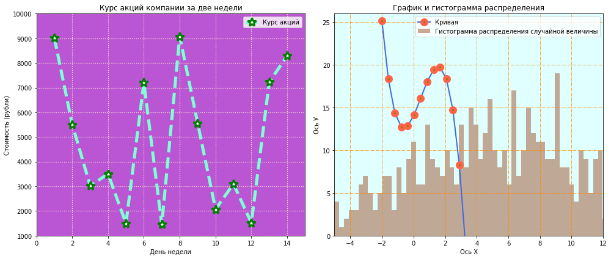

```python
import matplotlib.pylab as plt
import numpy as np
import random

# Набор координат для первого графика: Стоимость акций компании
y = [9025, 5510,  3030, 3500,  1500, 7200,  1460,9080, 5564,  2070, 3100,  1520, 7230,  8290,]
x = [1, 2, 3, 4, 5, 6, 7, 8, 9, 10, 11, 12, 13, 14,]

# Массив данных для построения гистограммы
gistogram_mas = [random.gauss(5,7) for _ in range(600)]

# Координаты для построения произвольной кривой
kriv_x = np.linspace(-2,18,50)
kriv_y = []
for i in range(len(kriv_x)):
    # Здесь вычисляем значения координат для оси y
    kriv_y.append((-1.4) * kriv_x[i]**3 + 2 * kriv_x[i]**2 +4 * kriv_x[i] + 14)

# 2 графика в 1 строке
figure, axes = plt.subplots(figsize = (14,6), nrows = 1, ncols = 2)

axes[0].plot(x,
           y,
           color = '#7FFFD4',
           lw = 5,
           ls = '--',
           label = 'Курс акций',
           marker = '*',
           markersize = 15,
           markerfacecolor = '#F0FFF0',
           markeredgewidth = 3,
           markeredgecolor = 'green');
axes[0].set_ylim([1000, 10000])
axes[0].set_xlim([0, 15])
axes[0].legend(loc = 'upper right')
axes[0].set_xlabel('День недели')
axes[0].set_ylabel('Стоимость (рубли)')
axes[0].set_title("Курс акций компании за две недели")

# Сетка указанного цвета, из точек, ширина линии 1.2
axes[0].grid(color = '#FFEFD5', ls = ':', lw = 1.2)
axes[0].set_facecolor('#BA55D3')



bins = np.linspace(-5, 25, 100)

axes[1].hist(gistogram_mas, bins, alpha = 0.5, label = 'Гистограмма распределения случайной величины', color = '#A0522D')
axes[1].plot(kriv_x,
           kriv_y,
           color = '#4169E1',
           lw = 2,
           ls = '-',
           label = 'Кривая',
           marker = 'o',
           markersize = 8,
           markerfacecolor = '#808000',
           markeredgewidth = 5,
           markeredgecolor = '#FF6347');
axes[1].set_ylim([0, 26])
axes[1].set_xlim([-5, 12])
axes[1].legend(loc = 'upper right')
axes[1].set_xlabel('Ось Х')
axes[1].set_ylabel('Ось У')
axes[1].set_title('График и гистограмма распределения')

# Сетка темно-оранжевого цвета, линия:-., ширина линии 0.8
axes[1].grid(color = '#FF8C00', ls = '-.', lw = 0.8)
axes[1].set_facecolor('#E0FFFF')

figure
plt.tight_layout()
```

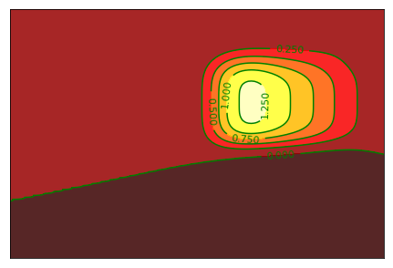

```python
import numpy as np
import matplotlib.pyplot as plt

def f(x,y):
    return (1-2*x/2+x**4+y**7)*np.exp(-3*x**4-2*y**4)

n = 128
x = np.linspace(-3,1,n)
y = np.linspace(-3,1.8,n)
X,Y = np.meshgrid(x,y)

plt.axes([0.025,0.025,0.95,0.95])

plt.contourf(X, Y, f(X,Y), 5, alpha=.85, cmap=plt.cm.hot)
C = plt.contour(X, Y, f(X,Y), 5, colors='green', linewidth=.4)
plt.clabel(C, inline = 4, fontsize=11)

plt.xticks([]), plt.yticks([])

plt.show()
```

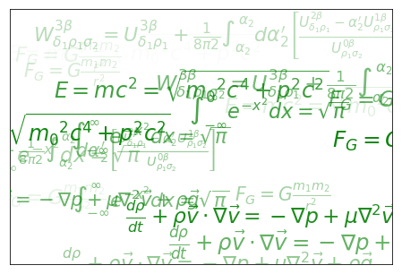

```python
# Формулы

import numpy as np
import matplotlib.pyplot as plt

eqs = []
eqs.append((r"$W^{3\beta}_{\delta_1 \rho_1 \sigma_2} = U^{3\beta}_{\delta_1 \rho_1} + \frac{1}{8 \pi 2} \int^{\alpha_2}_{\alpha_2} d \alpha^\prime_2 \left[\frac{ U^{2\beta}_{\delta_1 \rho_1} - \alpha^\prime_2U^{1\beta}_{\rho_1 \sigma_2} }{U^{0\beta}_{\rho_1 \sigma_2}}\right]$"))
eqs.append((r"$\frac{d\rho}{d t} + \rho \vec{v}\cdot\nabla\vec{v} = -\nabla p + \mu\nabla^2 \vec{v} + \rho \vec{g}$"))
eqs.append((r"$\int_{-\infty}^\infty e^{-x^2}dx=\sqrt{\pi}$"))
eqs.append((r"$E = mc^2 = \sqrt{{m_0}^2c^4 + p^2c^2}$"))
eqs.append((r"$F_G = G\frac{m_1m_2}{r^2}$"))


plt.axes([0.03,0.03,0.99,0.99])

for i in range(21):
    index = np.random.randint(0,len(eqs))
    eq = eqs[index]
    size = np.random.uniform(20,25)
    x,y = np.random.uniform(0,1,2)
    alpha = np.random.uniform(0,25)
    plt.text(x, y, eq, ha='center', va='center', color="green", alpha=alpha,
             transform=plt.gca().transAxes, fontsize=size, clip_on=True)

plt.xticks([]), plt.yticks([])

plt.show()
```

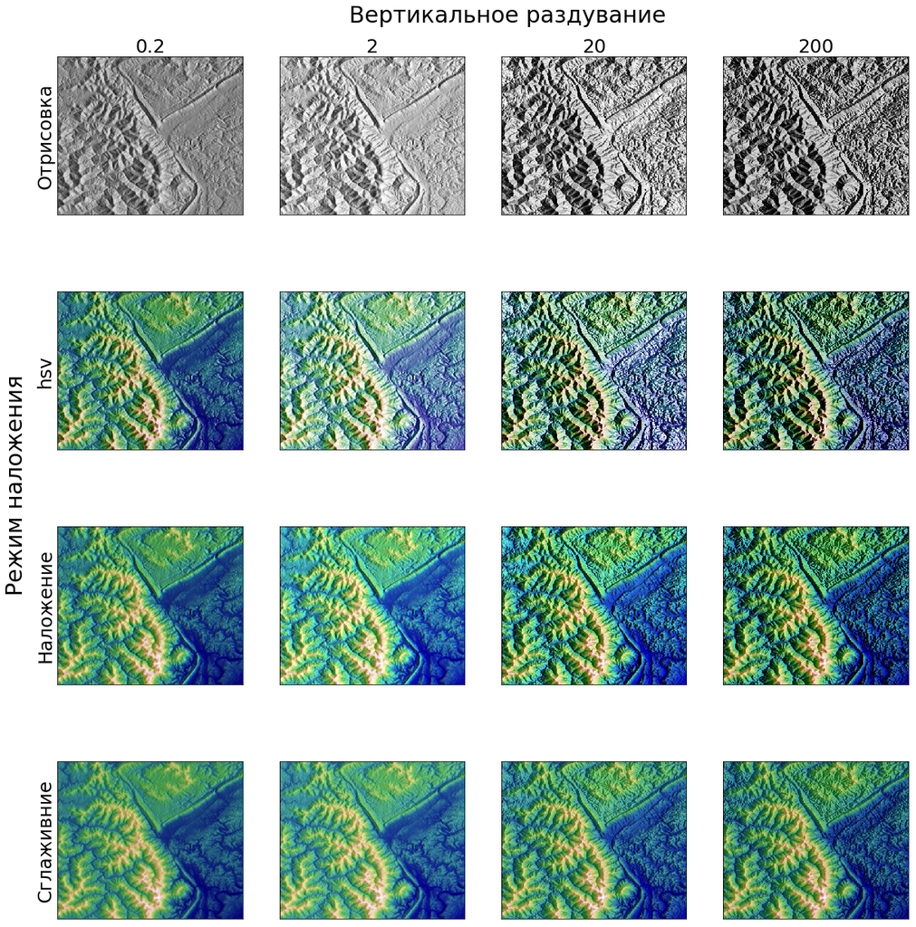

```python
# Геодезия

import numpy as np
import matplotlib.pyplot as plt
from matplotlib.cbook import get_sample_data
from matplotlib.colors import LightSource

dem = np.load(get_sample_data('jacksboro_fault_dem.npz'))
z = dem['elevation']

#-- Опционные dx и dy для точного вертикального преувеличения --------------------

dx, dy = dem['dx'], dem['dy']
dy = 151200 * dy
dx = 151200 * dx * np.cos(np.radians(dem['ymin']))


# Тень с востока, с Солнцем 45 градусов от горизонта
light_sources = LightSource(azdeg=90, altdeg=45)
cmap = plt.cm.gist_earth

fig, axes = plt.subplots(nrows=4, ncols=4, figsize=(19, 20))
plt.setp(axes.flat, xticks=[], yticks=[])

# Изменение вертикального преувеличения и режима наложения и построение всех комбинаций
for col, ver in zip(axes.T, [0.2, 2, 20, 200]):
    # Показать изображение интенсивности отмывки в первой строке
    col[0].imshow(light_sources.hillshade(z, vert_exag=ver, dx=dx, dy=dy), cmap='gray')

    # Поместитm затененные участки с различными режимами наложения в остальные строки
    for axs, mode in zip(col[1:], ['hsv', 'overlay', 'soft']):
        rgb = light_sources.shade(z, cmap=cmap, blend_mode=mode,
                       vert_exag=ver, dx=dx, dy=dy)
        axs.imshow(rgb)

# Строки и столбцы меток
for axs, ver in zip(axes[0], [0.2, 2, 20, 200]):
    axs.set_title('{0}'.format(ver), size=25)
for axs, mode in zip(axes[:, 0], ['Отрисовка', 'hsv', 'Наложение', 'Сглаживние']):
    axs.set_ylabel(mode, size=25)

# Метки групп
axes[0, 1].annotate('Вертикальное раздувание', (0.5, 1), xytext=(180, 40),
                    textcoords='offset points', xycoords='axes fraction',
                    ha='center', va='bottom', size=30)
axes[2, 0].annotate('Режим наложения', (0, 0.5), xytext=(-40, 160),
                    textcoords='offset points', xycoords='axes fraction',
                    ha='right', va='center', size=30, rotation=90)
fig.subplots_adjust(bottom=0.05, right=0.95)

plt.show()
```